# Pulsify: Spotify Track Recommendation System

Selim Erenay, Omer Erenay

2025-04-27

# Introduction

This project builds a **content-based song recommendation system** using Spotify track data.  
We use audio features such as `danceability`, `energy`, `valence`, `tempo`, and `acousticness` to find songs that are musically similar to a selected track.

# Data Loading

```r
# Load dataset
data <- read_csv("dataset.csv")
```

```
## ──────────────────────────────────────────────────────── Delimiter: "," chr
## (5): track_id, artists, album_name, track_name, track_genre dbl (15): ...1,
## popularity, duration_ms, danceability, energy, key, loudness... lgl (1):
## explicit
```

```r
# Quick overview
glimpse(data)
```

```
## Rows: 114,000
## Columns: 21
## $ ...1             <dbl> 0, 1, 2, 3, 4, 5, 6, 7, 8, 9, 10, 11, 12, 13, 14, 15,…
## $ track_id         <chr> "5SuOikwiRyPMVoIQDJUgSV", "4qPNDBW1i3p13qLCt0Ki3A", "…
## $ artists          <chr> "Gen Hoshino", "Ben Woodward", "Ingrid Michaelson;ZAY…
## $ album_name       <chr> "Comedy", "Ghost (Acoustic)", "To Begin Again", "Craz…
## $ track_name       <chr> "Comedy", "Ghost - Acoustic", "To Begin Again", "Can'…
## $ popularity       <dbl> 73, 55, 57, 71, 82, 58, 74, 80, 74, 56, 74, 69, 52, 6…
## $ duration_ms      <dbl> 230666, 149610, 210826, 201933, 198853, 214240, 22940…
## $ explicit         <lgl> FALSE, FALSE, FALSE, FALSE, FALSE, FALSE, FALSE, FALS…
## $ danceability     <dbl> 0.676, 0.420, 0.438, 0.266, 0.618, 0.688, 0.407, 0.70…
## $ energy           <dbl> 0.4610, 0.1660, 0.3590, 0.0596, 0.4430, 0.4810, 0.147…
## $ key              <dbl> 1, 1, 0, 0, 2, 6, 2, 11, 0, 1, 8, 4, 7, 3, 2, 4, 2, 1…
## $ loudness         <dbl> -6.746, -17.235, -9.734, -18.515, -9.681, -8.807, -8.…
## $ mode             <dbl> 0, 1, 1, 1, 1, 1, 1, 1, 1, 1, 1, 1, 0, 1, 1, 1, 1, 0,…
## $ speechiness      <dbl> 0.1430, 0.0763, 0.0557, 0.0363, 0.0526, 0.1050, 0.035…
## $ acousticness     <dbl> 0.0322, 0.9240, 0.2100, 0.9050, 0.4690, 0.2890, 0.857…
## $ instrumentalness <dbl> 1.01e-06, 5.56e-06, 0.00e+00, 7.07e-05, 0.00e+00, 0.0…
## $ liveness         <dbl> 0.3580, 0.1010, 0.1170, 0.1320, 0.0829, 0.1890, 0.091…
## $ valence          <dbl> 0.7150, 0.2670, 0.1200, 0.1430, 0.1670, 0.6660, 0.076…
## $ tempo            <dbl> 87.917, 77.489, 76.332, 181.740, 119.949, 98.017, 141…
## $ time_signature   <dbl> 4, 4, 4, 3, 4, 4, 3, 4, 4, 4, 4, 3, 4, 4, 4, 3, 4, 4,…
## $ track_genre      <chr> "acoustic", "acoustic", "acoustic", "acoustic", "acou…
```

```r
summary(data)
```

```
##       ...1          track_id           artists           album_name
##  Min.   :     0   Length:114000      Length:114000      Length:114000
##  1st Qu.: 28500   Class :character   Class :character   Class :character
##  Median : 57000   Mode  :character   Mode  :character   Mode  :character
##  Mean   : 57000
##  3rd Qu.: 85499
##  Max.   :113999
##   track_name          popularity      duration_ms       explicit
##  Length:114000      Min.   :  0.00   Min.   :      0   Mode :logical
##  Class :character   1st Qu.: 17.00   1st Qu.: 174066   FALSE:104253
##  Mode  :character   Median : 35.00   Median : 212906   TRUE :9747
##                     Mean   : 33.24   Mean   : 228029
##                     3rd Qu.: 50.00   3rd Qu.: 261506
##                     Max.   :100.00   Max.   :5237295
##   danceability        energy            key            loudness
##  Min.   :0.0000   Min.   :0.0000   Min.   : 0.000   Min.   :-49.531
##  1st Qu.:0.4560   1st Qu.:0.4720   1st Qu.: 2.000   1st Qu.:-10.013
##  Median :0.5800   Median :0.6850   Median : 5.000   Median : -7.004
##  Mean   :0.5668   Mean   :0.6414   Mean   : 5.309   Mean   : -8.259
##  3rd Qu.:0.6950   3rd Qu.:0.8540   3rd Qu.: 8.000   3rd Qu.: -5.003
##  Max.   :0.9850   Max.   :1.0000   Max.   :11.000   Max.   :  4.532
##       mode         speechiness       acousticness    instrumentalness
##  Min.   :0.0000   Min.   :0.00000   Min.   :0.0000   Min.   :0.00e+00
##  1st Qu.:0.0000   1st Qu.:0.03590   1st Qu.:0.0169   1st Qu.:0.00e+00
##  Median :1.0000   Median :0.04890   Median :0.1690   Median :4.16e-05
##  Mean   :0.6376   Mean   :0.08465   Mean   :0.3149   Mean   :1.56e-01
##  3rd Qu.:1.0000   3rd Qu.:0.08450   3rd Qu.:0.5980   3rd Qu.:4.90e-02
##  Max.   :1.0000   Max.   :0.96500   Max.   :0.9960   Max.   :1.00e+00
##     liveness         valence           tempo        time_signature
##  Min.   :0.0000   Min.   :0.0000   Min.   :  0.00   Min.   :0.000
##  1st Qu.:0.0980   1st Qu.:0.2600   1st Qu.: 99.22   1st Qu.:4.000
##  Median :0.1320   Median :0.4640   Median :122.02   Median :4.000
##  Mean   :0.2136   Mean   :0.4741   Mean   :122.15   Mean   :3.904
##  3rd Qu.:0.2730   3rd Qu.:0.6830   3rd Qu.:140.07   3rd Qu.:4.000
##  Max.   :1.0000   Max.   :0.9950   Max.   :243.37   Max.   :5.000
##  track_genre
##  Length:114000
##  Class :character
##  Mode  :character
##
##
##
```

# Data Preprocessing

We selected relevant audio features and normalized them to ensure fair comparisons.

```r
# Selecting important features
features <- data %>%
  select(track_name, artists, danceability, energy, valence, tempo, acousticness) %>%
  na.omit()

# Normalizing numerical features
features_normalized <- features %>%
  mutate(across(c(danceability, energy, valence, tempo, acousticness),
                ~ scale(.)[,1]))
```

# Building the Recommendation System

We created a function `recommend_track()` that: - Selects the most popular version of a track - Compares all songs to it using **Euclidean distance** - Returns the top 10 most similar songs - Plots the results - Saves recommendations automatically to a CSV file

```r
recommend_track <- function(song_title) {
  most_popular_row <- data %>%
    filter(track_name == song_title) %>%
    arrange(desc(popularity)) %>%
    slice(1)

  reference <- features_normalized %>%
    filter(track_name == most_popular_row$track_name,
           artists == most_popular_row$artists) %>%
    select(danceability, energy, valence, tempo, acousticness) %>%
    slice(1)

  comparison_data <- features_normalized %>%
    select(danceability, energy, valence, tempo, acousticness)

  distances <- proxy::dist(comparison_data, reference, method = "euclidean")

  features_with_distance <- features_normalized %>%
    mutate(distance = as.vector(distances))

  recommendations <- features_with_distance %>%
    filter(track_name != most_popular_row$track_name | artists != most_popular_row$artists) %>%
    arrange(distance) %>%
    distinct(track_name, artists, .keep_all = TRUE) %>%
    select(track_name, artists, distance) %>%
    slice(1:10)

  # Plot
  plot <- ggplot(recommendations, aes(x = reorder(track_name, -distance), y = distance)) +
    geom_col(fill = "steelblue") +
    coord_flip() +
    labs(title = paste("Top 10 Songs Similar to", song_title),
         x = "Track Name", y = "Distance")

  print(plot)

  # Export CSV
  filename <- paste0(gsub(" ", "_", tolower(song_title)), "_recommendations.csv")
  write_csv(recommendations, filename)

  return(recommendations)
}
```

# Running the Recommendation System

Example: finding songs similar to **“Blinding Lights”**.

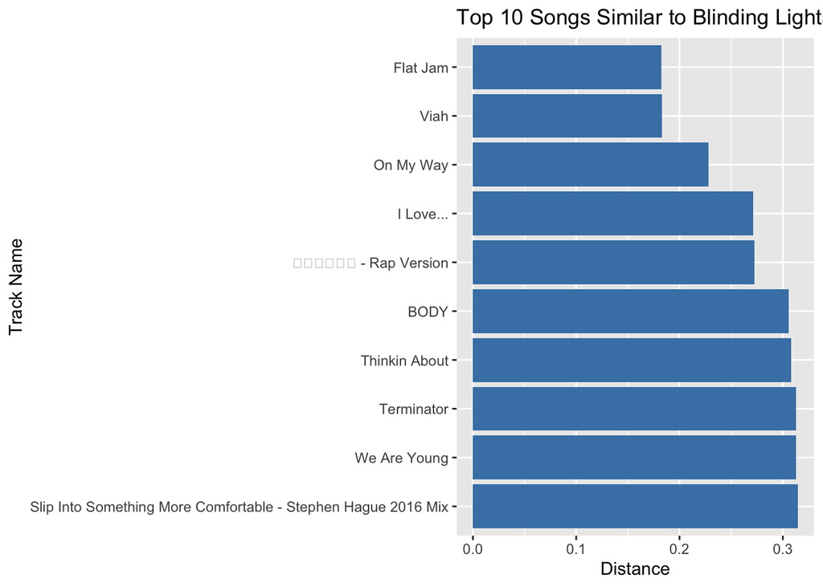

```
## # A tibble: 10 × 3
##    track_name                                                   artists distance
##    <chr>                                                        <chr>      <dbl>
##  1 Flat Jam                                                     Pola &…    0.182
##  2 Viah                                                         Jass M…    0.183
##  3 On My Way                                                    Alan W…    0.228
##  4 I Love...                                                    Offici…    0.271
##  5 平凡人的自傳 - Rap Version                                   ONE PR…    0.272
##  6 BODY                                                         LICK;L…    0.306
##  7 Thinkin About                                                ShockO…    0.308
##  8 Terminator                                                   Sevend…    0.313
##  9 We Are Young                                                 Juveni…    0.313
## 10 Slip Into Something More Comfortable - Stephen Hague 2016 M… Kinobe…    0.315
```

```r
recommend_track("Blinding Lights")
```

# Conclusion

Using normalized audio features and Euclidean distance, we successfully built a content-based recommendation engine.  
This system recommends the top 10 most similar songs to any chosen track and saves results for further analysis.

After each function call, the top 10 recommended songs are automatically exported into a CSV file, named based on the selected track (e.g., `blinding_lights_recommendations.csv`). This allows for easy retrieval and sharing of recommendation results.